# Question 1

# 7. Reduced Model:

```r
newmodel <- glm(Outcome ~ Glucose+BMI+Age, family=binomial(link='logit'),
             data=train_no_insulin)
summary(newmodel)
```

```
##
## Call:
## glm(formula = Outcome ~ Glucose + BMI + Age, family = binomial(link = "logit"),
##     data = train_no_insulin)
##
## Coefficients:
##              Estimate Std. Error z value Pr(>|z|)
## (Intercept) -9.656787   1.067566  -9.046  < 2e-16 ***
## Glucose      0.036312   0.004858   7.475 7.72e-14 ***
## BMI          0.073727   0.021904   3.366 0.000763 ***
## Age          0.056961   0.012834   4.438 9.06e-06 ***
## ---
## Signif. codes:  0 '***' 0.001 '**' 0.01 '*' 0.05 '.' 0.1 ' ' 1
##
## (Dispersion parameter for binomial family taken to be 1)
##
##     Null deviance: 473.12  on 374  degrees of freedom
## Residual deviance: 328.60  on 371  degrees of freedom
## AIC: 336.6
##
## Number of Fisher Scoring iterations: 5
```

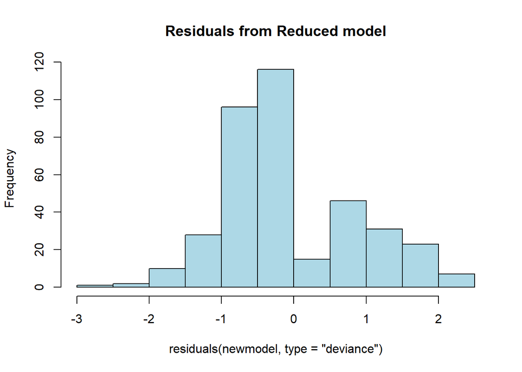

```r
hist(residuals(newmodel, type="deviance"), main="Residuals from Reduced model", col="lightblue")
```

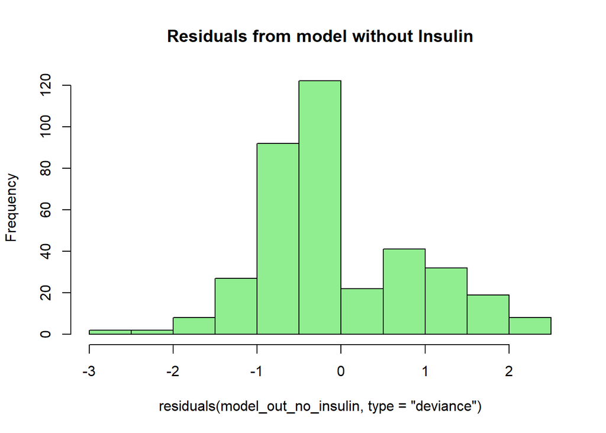

```r
hist(residuals(model_out_no_insulin, type="deviance"), main="Residuals from model without Insulin", col="lightgreen")
```

**Predictions for the Reduced Model**

```r
##Acuracy for training data
pred_probs <- predict(newmodel, type="response")
pred_class <- ifelse(pred_probs > 0.5, 1, 0)
confusionMatrix(as.factor(pred_class), as.factor(train_no_insulin$Outcome))
```

```
## Confusion Matrix and Statistics
##
##           Reference
## Prediction   0   1
##          0 227  47
##          1  26  75
##
##                Accuracy : 0.8053
##                  95% CI : (0.7616, 0.8442)
##     No Information Rate : 0.6747
##     P-Value [Acc > NIR] : 1.179e-08
##
##                   Kappa : 0.5359
##
##  Mcnemar's Test P-Value : 0.01924
##
##             Sensitivity : 0.8972
##             Specificity : 0.6148
##          Pos Pred Value : 0.8285
##          Neg Pred Value : 0.7426
##              Prevalence : 0.6747
##          Detection Rate : 0.6053
##    Detection Prevalence : 0.7307
##       Balanced Accuracy : 0.7560
##
##        'Positive' Class : 0
##
```

```r
#Accuracy for testing data
pred_probs_test <- predict(newmodel, newdata=test_no_insulin, type="response")
pred_class_test <- ifelse(pred_probs_test > 0.5, 1, 0)
confusionMatrix(as.factor(pred_class_test), as.factor(test_no_insulin$Outcome))
```

```
## Confusion Matrix and Statistics
##
##           Reference
## Prediction  0  1
##          0 87 29
##          1 15 26
##
##                Accuracy : 0.7197
##                  95% CI : (0.6426, 0.7884)
##     No Information Rate : 0.6497
##     P-Value [Acc > NIR] : 0.03779
##
##                   Kappa : 0.346
##
##  Mcnemar's Test P-Value : 0.05002
##
##             Sensitivity : 0.8529
##             Specificity : 0.4727
##          Pos Pred Value : 0.7500
##          Neg Pred Value : 0.6341
##              Prevalence : 0.6497
##          Detection Rate : 0.5541
##    Detection Prevalence : 0.7389
##       Balanced Accuracy : 0.6628
##
##        'Positive' Class : 0
##
```

Conclusions: The accuracy and the residuals for the reduced model and the model without insulin are similar, the AIC for the reduced model increased 4 points. Even so, the reduced model is less complex and has similar results.

**AUC-ROC**

```r
#install.packages("pROC")
#install.packages("randomForest")
library(pROC)
library(randomForest)
set.seed(420)

#ROC for Model without insulin
Outcome_train_noinsulin=train_no_insulin[,8]
predictions1=predict(model_out_no_insulin)
roc1=roc(Outcome_train_noinsulin ~ predictions1)
##ROC for Reduced Model
predictions2=predict(newmodel)
roc2=roc(Outcome_train_noinsulin ~ predictions2)
```

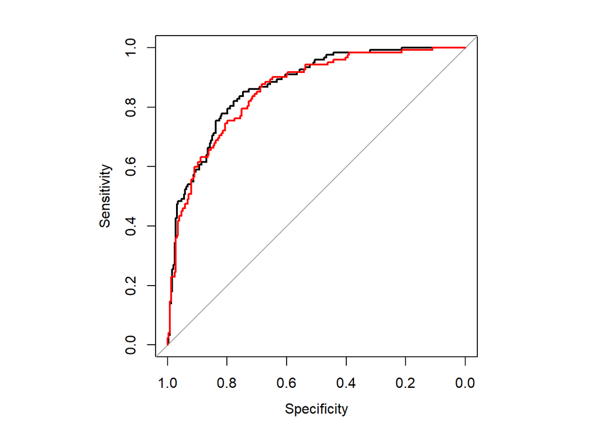

```r
##Graph
par(pty="s")
plot(roc1)
plot(roc2, add=TRUE, col='red')
```

```r
names(roc2)
```

```
##  [1] "percent"            "sensitivities"      "specificities"
##  [4] "thresholds"         "direction"          "cases"
##  [7] "controls"           "fun.sesp"           "auc"
## [10] "call"               "original.predictor" "original.response"
## [13] "predictor"          "response"           "levels"
## [16] "predictor.name"     "response.name"
```

```r
##Area under the curve
AUC_noinsulin=roc1$auc
AUC_reducedmodel=roc2$auc
print(paste("The AUC for the model without Insulin is", AUC_noinsulin))
```

```
## [1] "The AUC for the model without Insulin is 0.871444307652433"
```

```r
print(paste("The AUC for the reduced model is",AUC_reducedmodel))
```

```
## [1] "The AUC for the reduced model is 0.857966694745027"
```

It can be seen that the curve of the reduced model in red does not deviate too much from the curve of the original model. Moreover, the AUC values for both models are similar. In conclussion the reduced model give me a better trade-off between accuracy and complexity.

# 8. Decision Tree:

```r
#install.packages("rpart")
#install.packages("rpart.plot")
library(rpart)
library(rpart.plot)
outcome_tree = rpart(Outcome ~ .,data=train_no_insulin)
summary(outcome_tree)
```

```
## Call:
## rpart(formula = Outcome ~ ., data = train_no_insulin)
##   n= 375
##
##           CP nsplit rel error    xerror       xstd
## 1 0.35245902      0 1.0000000 1.0000000 0.07436434
## 2 0.03688525      1 0.6475410 0.6803279 0.06589539
## 3 0.03278689      3 0.5737705 0.6967213 0.06645582
## 4 0.01639344      5 0.5081967 0.6721311 0.06560928
## 5 0.01000000      7 0.4754098 0.7131148 0.06700086
##
## Variable importance
##                  Glucose                      Age DiabetesPedigreeFunction
##                       52                       19                        9
##                      BMI            SkinThickness              Pregnancies
##                        8                        5                        4
##            BloodPressure
##                        3
##
## Node number 1: 375 observations,    complexity param=0.352459
##   predicted class=0  expected loss=0.3253333  P(node) =1
##     class counts:   253   122
##    probabilities: 0.675 0.325
##   left son=2 (282 obs) right son=3 (93 obs)
##   Primary splits:
##       Glucose                  < 143.5  to the left,  improve=40.740380, (0 missing)
##       Age                      < 42.5   to the left,  improve=19.323490, (0 missing)
##       Pregnancies              < 6.5    to the left,  improve=12.414070, (0 missing)
##       BMI                      < 29.65  to the left,  improve=11.023950, (0 missing)
##       DiabetesPedigreeFunction < 0.3185 to the left,  improve= 8.354083, (0 missing)
##   Surrogate splits:
##       DiabetesPedigreeFunction < 1.149  to the left,  agree=0.765, adj=0.054, (0 split)
##       Age                      < 50.5   to the left,  agree=0.763, adj=0.043, (0 split)
##       SkinThickness            < 55     to the left,  agree=0.757, adj=0.022, (0 split)
##       BMI                      < 48.05  to the left,  agree=0.757, adj=0.022, (0 split)
##       Pregnancies              < 12.5   to the left,  agree=0.755, adj=0.011, (0 split)
##
## Node number 2: 282 observations,    complexity param=0.03688525
##   predicted class=0  expected loss=0.1914894  P(node) =0.752
##     class counts:   228    54
```

[output cut: 115 more lines]

```
##
## Node number 13: 13 observations
##   predicted class=1  expected loss=0.2307692  P(node) =0.03466667
##     class counts:     3    10
##    probabilities: 0.231 0.769
##
## Node number 22: 16 observations
##   predicted class=0  expected loss=0.4375  P(node) =0.04266667
##     class counts:     9     7
##    probabilities: 0.562 0.437
##
## Node number 23: 13 observations
##   predicted class=1  expected loss=0.07692308  P(node) =0.03466667
##     class counts:     1    12
##    probabilities: 0.077 0.923
```

```r
##Predictions training and testing

predictions_Outcome_trainig = predict(outcome_tree, newdata=train_no_insulin, type='class')
head( predictions_Outcome_trainig )
```

```
##  2  4  7 14 15 17
##  0  0  0  1  1  1
## Levels: 0 1
```

```r
predictions_Outcome_testing = predict(outcome_tree, newdata=test_no_insulin, type='class')

##Accuracy trainig and testing

accuracytraining <- mean(predictions_Outcome_trainig == train_no_insulin$Outcome)
accuracytesting <- mean(predictions_Outcome_testing == test_no_insulin$Outcome)
accuracytraining
```

```
## [1] 0.8453333
```

```r
accuracytesting
```

```
## [1] 0.7261146
```

```r
## Confusion Matrix for training

confusionMatrix(predictions_Outcome_trainig, train_no_insulin$Outcome)$table
```

```
##           Reference
## Prediction   0   1
##          0 235  40
##          1  18  82
```

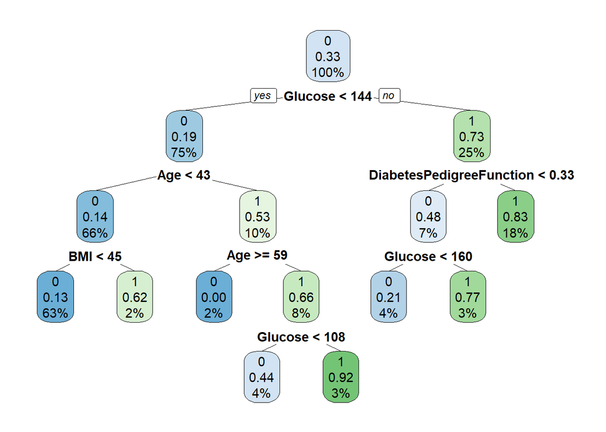

```r
##Draw the tree model

#library(rattle)
#fancyRpartPlot(outcome_tree)

rpart.plot(outcome_tree, fallen.leaves = FALSE)
```

```r
##Variable Importance
outcome_tree$variable.importance
```

```
##                  Glucose                      Age DiabetesPedigreeFunction
##                48.533763                17.985334                 7.975374
##                      BMI            SkinThickness              Pregnancies
##                 7.139254                 4.406749                 4.050857
##            BloodPressure
##                 2.836745
```

The Training and testing accuracy are 84.5% and 72.6% respectively. In the graph it is observed that 33% of the observations in the training dataset are diabetic and the first decision node is glucose, if glucose is > 144 the probability of being diabetic is 73%.

# 9.

The decision tree is as accurate as the logistic regression model in this case, because of it’s simplicity it is very useful to understand how to categorize each patient and the probabilities of a patient having diabetes depending on his values for Glucose, Age, Diabetes Pedigree Function and BMI.

In the decision tree, the variable Diabetes Pedigree Function is more important that the variable BMI, in comparison with the logistic regression model where the removal of Diabetes Pedigree Function didn’t affect the outcome.

Since decisions can be visualized in such an intuitive way, it is a pragmatic method for diagnosing the patient.

# 10.

Although both models are similar in accuracy, with the decision tree performing 5% better on training data. Because the simplicity of the Decision Tree, the Decision Tree model gives a better trade off between accuracy and complexity.

# 11. Scaling the data:

```r
#Data scaled without insulin
numeric_cols <- datasetdiabetes_no_insulin[sapply(datasetdiabetes_no_insulin, is.numeric)]

# Scale the numeric columns
scaled_data_noinsulin <- as.data.frame(scale(numeric_cols))
scaled_data_noinsulin$Outcome <- datasetdiabetes_no_insulin[["Outcome"]]
head(scaled_data_noinsulin)
```

```
##   Pregnancies    Glucose BloodPressure SkinThickness        BMI
## 1   0.6395305  0.8617221   -0.03272323    0.55804049  0.1649875
## 2  -0.8443348 -1.2014407   -0.51729142   -0.01464349 -0.8458446
## 3   1.2330766  2.0079237   -0.67881415            NA -1.3223797
## 4  -0.8443348 -1.0704463   -0.51729142   -0.58732747 -0.6292377
## 5  -1.1411079  0.5014873   -2.61708691    0.55804049  1.5368309
## 6   0.3427574 -0.1862336    0.12879950            NA -0.9902491
##   DiabetesPedigreeFunction         Age Outcome
## 1                0.4681869  1.42506672       1
## 2               -0.3648230 -0.19054773       0
## 3                0.6040037 -0.10551539       1
## 4               -0.9201630 -1.04087112       0
## 5                5.4813370 -0.02048305       1
## 6               -0.8175458 -0.27558007       0
```

```r
names(scaled_data_noinsulin)
```

```
## [1] "Pregnancies"              "Glucose"
## [3] "BloodPressure"            "SkinThickness"
## [5] "BMI"                      "DiabetesPedigreeFunction"
## [7] "Age"                      "Outcome"
```

```r
#Is Outcome a factor?
is.factor(scaled_data_noinsulin$Outcome)
```

```
## [1] TRUE
```

```r
#training and testing scaled

set.seed(21)
n2=nrow(scaled_data_noinsulin)
sample2 <- sample(c(TRUE, FALSE), n2, replace=TRUE, prob=c(0.7,0.3))
training_scaled <-scaled_data_noinsulin[sample2,]
testing_scaled <-scaled_data_noinsulin[!sample2,]
```

# 12. Using Scaled Data

**Logistic Regression Model**

```r
#Logistic Regression Model:
Complete_model_scaled <- glm(Outcome ~ ., data = training_scaled, family = binomial() )
summary(Complete_model_scaled)
```

```
##
## Call:
## glm(formula = Outcome ~ ., family = binomial(), data = training_scaled)
##
## Coefficients:
##                          Estimate Std. Error z value Pr(>|z|)
## (Intercept)               -0.9911     0.1507  -6.576 4.84e-11 ***
## Pregnancies                0.2728     0.1943   1.404   0.1602
## Glucose                    1.1375     0.1557   7.306 2.75e-13 ***
## BloodPressure             -0.2573     0.1502  -1.713   0.0867 .
## SkinThickness              0.1040     0.1898   0.548   0.5837
## BMI                        0.5320     0.2043   2.604   0.0092 **
## DiabetesPedigreeFunction   0.3599     0.1560   2.307   0.0211 *
## Age                        0.5608     0.2061   2.722   0.0065 **
## ---
## Signif. codes:  0 '***' 0.001 '**' 0.01 '*' 0.05 '.' 0.1 ' ' 1
##
## (Dispersion parameter for binomial family taken to be 1)
##
##     Null deviance: 473.12  on 374  degrees of freedom
## Residual deviance: 317.01  on 367  degrees of freedom
##   (150 observations deleted due to missingness)
## AIC: 333.01
##
## Number of Fisher Scoring iterations: 5
```

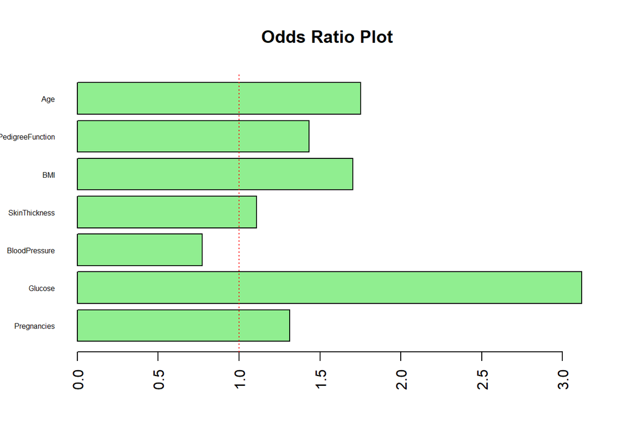

```r
# Analyzing Odds Ratios
odds_ratios <- exp(coef(Complete_model_scaled))
# no intercept from the odds_ratios
odds_ratios_noint= odds_ratios[-1]
barplot(odds_ratios_noint, beside=TRUE, las=2, main="Odds Ratio Plot", horiz=TRUE, col="lightgreen", border="black", cex.names=0.5)
abline(v = 1, col = "red", lty = 3)
```

```r
#Accuracy for testing data
predicted_probs_s <- predict(Complete_model_scaled, newdata=testing_scaled, type="response")
predicted_class_s <- ifelse(predicted_probs_s > 0.5, 1, 0)
confusionMatrix(as.factor(predicted_class_s), as.factor(testing_scaled$Outcome))$table
```

```
##           Reference
## Prediction  0  1
##          0 87 26
##          1 15 29
```

```r
confusionMatrix(as.factor(predicted_class_s), as.factor(testing_scaled$Outcome))$overall
```

```
##       Accuracy          Kappa  AccuracyLower  AccuracyUpper   AccuracyNull
##     0.73885350     0.39857984     0.66283844     0.80562264     0.64968153
## AccuracyPValue  McnemarPValue
##     0.01071629     0.11834981
```

There isn’t an observed change in the levels of significance of the p-values, the variables: Glucose, BMI and Age are the most statistically significant. The coefficients changed and now the odd ratio table is accurate, selecting Glucose as the variable that produces higher odds instead of Diabetes Pedigree Function.

The AIC, accuracy and confusion matrix remain the same.

**Reduced Regression Model**

```r
#Reduced Regression Model:
reduced_model_scaled <- glm(Outcome ~ Glucose+BMI+Age, family=binomial(link='logit'),
             data=training_scaled)
summary(reduced_model_scaled)
```

```
##
## Call:
## glm(formula = Outcome ~ Glucose + BMI + Age, family = binomial(link = "logit"),
##     data = training_scaled)
##
## Coefficients:
##             Estimate Std. Error z value Pr(>|z|)
## (Intercept)  -0.9041     0.1178  -7.674 1.66e-14 ***
## Glucose       1.0895     0.1263   8.627  < 2e-16 ***
## BMI           0.5913     0.1234   4.792 1.65e-06 ***
## Age           0.3521     0.1114   3.161  0.00157 **
## ---
## Signif. codes:  0 '***' 0.001 '**' 0.01 '*' 0.05 '.' 0.1 ' ' 1
##
## (Dispersion parameter for binomial family taken to be 1)
##
##     Null deviance: 660.44  on 516  degrees of freedom
## Residual deviance: 488.03  on 513  degrees of freedom
##   (8 observations deleted due to missingness)
## AIC: 496.03
##
## Number of Fisher Scoring iterations: 5
```

```r
#Accuracy for testing data
predicted_probs_r <- predict(reduced_model_scaled, newdata=testing_scaled, type="response")
predicted_class_r <- ifelse(predicted_probs_r > 0.5, 1, 0)
confusionMatrix(as.factor(predicted_class_r), as.factor(testing_scaled$Outcome))$table
```

```
##           Reference
## Prediction   0   1
##          0 128  42
##          1  17  48
```

```r
confusionMatrix(as.factor(predicted_class_r), as.factor(testing_scaled$Outcome))$overall
```

```
##       Accuracy          Kappa  AccuracyLower  AccuracyUpper   AccuracyNull
##   0.7489361702   0.4392315470   0.6884300140   0.8030452910   0.6170212766
## AccuracyPValue  McnemarPValue
##   0.0000129118   0.0017808702
```

The AIC for this model keeps being larger than the complete model, but it is accurate and less complex.

**Decision Tree**

```r
#Decision Tree:
outcome_tree_scaled = rpart(Outcome ~ .,data=training_scaled)
summary(outcome_tree_scaled)
```

```
## Call:
## rpart(formula = Outcome ~ ., data = training_scaled)
##   n= 525
##
##           CP nsplit rel error    xerror       xstd
## 1 0.29142857      0 1.0000000 1.0000000 0.06172134
## 2 0.03142857      1 0.7085714 0.8114286 0.05816020
## 3 0.02285714      3 0.6457143 0.7828571 0.05749876
## 4 0.01714286      8 0.5314286 0.7371429 0.05636698
## 5 0.01142857     10 0.4971429 0.7428571 0.05651354
## 6 0.01000000     14 0.4514286 0.7714286 0.05722443
##
## Variable importance
##                  Glucose                      Age DiabetesPedigreeFunction
##                       47                       18                       13
##                      BMI              Pregnancies            BloodPressure
##                        9                        9                        4
##
## Node number 1: 525 observations,    complexity param=0.2914286
##   predicted class=0  expected loss=0.3333333  P(node) =1
##     class counts:   350   175
##    probabilities: 0.667 0.333
##   left son=2 (388 obs) right son=3 (137 obs)
##   Primary splits:
##       Glucose       < 0.5833589   to the left,  improve=46.239450, (3 missing)
##       Age           < -0.2330639  to the left,  improve=21.859380, (0 missing)
##       BMI           < -0.3765297  to the left,  improve=18.000060, (5 missing)
##       Pregnancies   < 0.787917    to the left,  improve=13.811540, (0 missing)
##       SkinThickness < -0.5396038  to the left,  improve= 8.648043, (145 missing)
##   Surrogate splits:
##       DiabetesPedigreeFunction < 2.043662    to the left,  agree=0.749, adj=0.044, (3 split)
##       Age                      < 2.062809    to the left,  agree=0.749, adj=0.044, (0 split)
##
## Node number 2: 388 observations,    complexity param=0.02285714
##   predicted class=0  expected loss=0.2087629  P(node) =0.7390476
##     class counts:   307    81
##    probabilities: 0.791 0.209
##   left son=4 (241 obs) right son=5 (147 obs)
##   Primary splits:
##       Age                      < -0.2330639  to the left,  improve=9.948781, (0 missing)
```

[output cut: 254 more lines]

```
##
## Node number 383: 27 observations
##   predicted class=1  expected loss=0.1851852  P(node) =0.05142857
##     class counts:     5    22
##    probabilities: 0.185 0.815
##
## Node number 764: 18 observations
##   predicted class=0  expected loss=0.3888889  P(node) =0.03428571
##     class counts:    11     7
##    probabilities: 0.611 0.389
##
## Node number 765: 19 observations
##   predicted class=1  expected loss=0.2631579  P(node) =0.03619048
##     class counts:     5    14
##    probabilities: 0.263 0.737
```

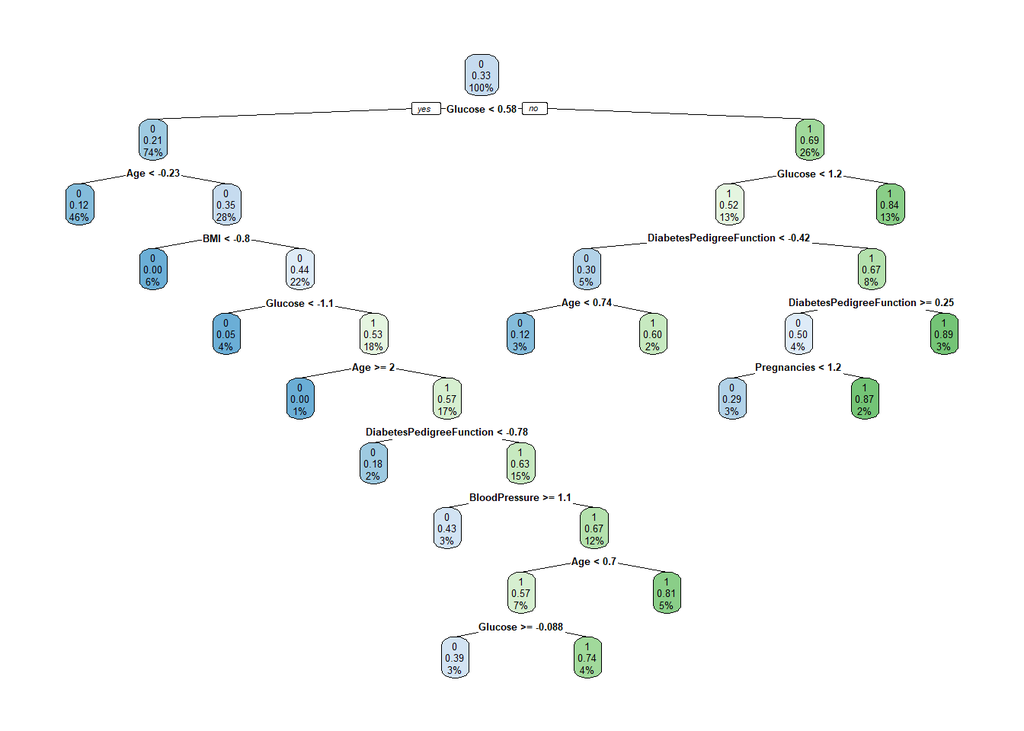

```r
rpart.plot(outcome_tree_scaled, fallen.leaves = FALSE)
```

```r
#Variable Importance
outcome_tree_scaled$variable.importance
```

```
##                  Glucose                      Age DiabetesPedigreeFunction
##                 65.13983                 25.43765                 17.94039
##                      BMI              Pregnancies            BloodPressure
##                 12.23408                 12.14003                  5.92835
```

```r
# Accuracy for testing data
predictions_Outcome_testing = predict(outcome_tree_scaled, newdata=testing_scaled, type='class')
accuracytesting_t <- mean(predictions_Outcome_testing == testing_scaled$Outcome)
accuracytesting_t
```

```
## [1] 0.7078189
```

```r
confusionMatrix(predictions_Outcome_testing, testing_scaled$Outcome)$table
```

```
##           Reference
## Prediction   0   1
##          0 129  50
##          1  21  43
```

The decision tree has a higher depth for the scaled data, this is due the less variability of the variables, that makes more difficult to find an accurate split. Then the model with scaled data is more complex and prone to overfitting.

# 13. K-means

K-means on diabetes dataset:

```r
datasetdiabetesNoNAs <-na.omit(datasetdiabetes_no_insulin) #Data without Nas and without insulin
numeric_datasetdiabetes=datasetdiabetesNoNAs[,1:7]

#install.packages("MASS")
library(MASS)
```

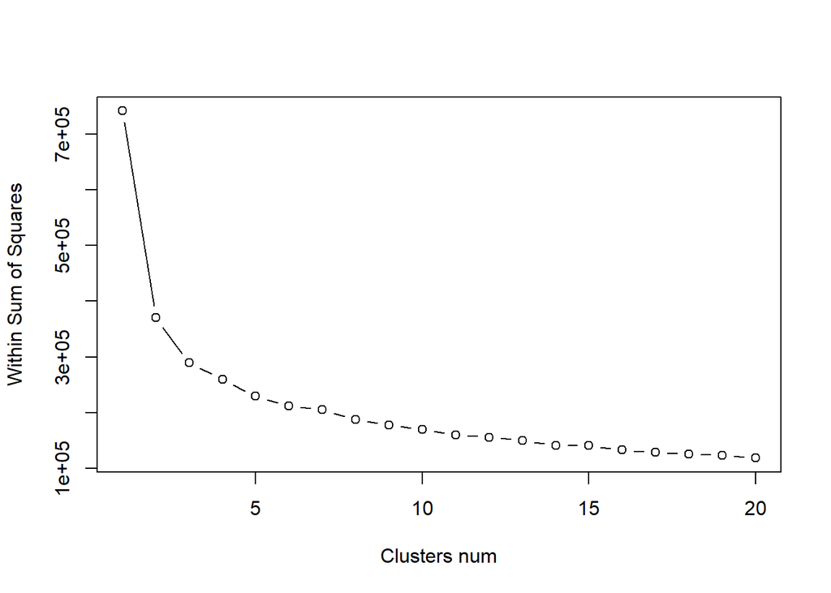

```r
clust_max = 20

#Within total sum of squares, for data
wss = c()

for( k in 1:clust_max) {
   kmeans_model = kmeans(datasetdiabetesNoNAs, centers=k)
   wss[k] = kmeans_model$tot.withinss
}

#Elbow - Plot
plot(1:clust_max, wss, type="b", xlab="Clusters num", ylab="Within Sum of Squares")
```

For the scaled data:

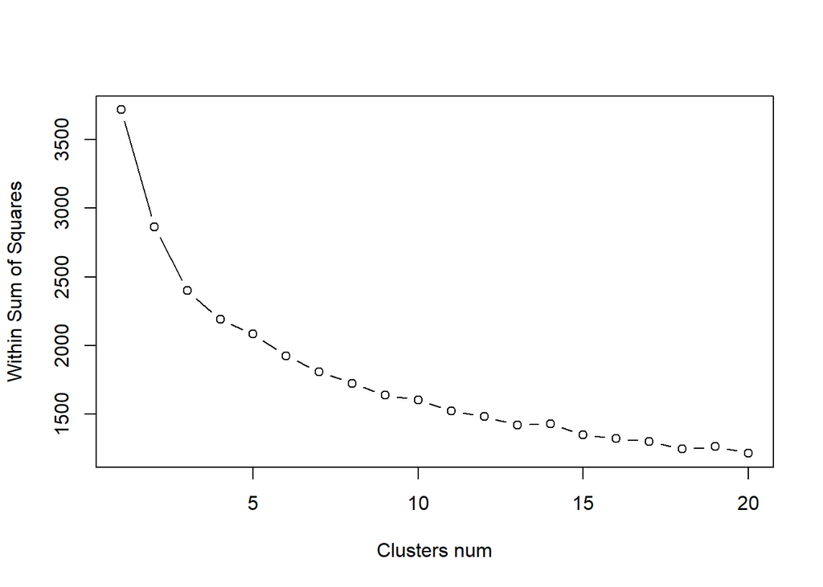

```r
#Within total sum of squares, for scale data
scale_datasediabetes <-scale(numeric_datasetdiabetes)
wss = c()

for( k in 1:clust_max) {
   kmeans_model = kmeans(scale_datasediabetes, centers=k)
   wss[k] = kmeans_model$tot.withinss
}
#Elbow - Plot
plot(1:clust_max, wss, type="b", xlab="Clusters num", ylab="Within Sum of Squares")
```

Conclusions: In the MSS plot for the data, we can observe an elbow, which indicates I should use 3 clusters, also because of the different measurements between the variables we can observe larger numbers in the MSS plot compared with the MSS plot for non scaled data. In the scaled data MSS plot, there is not a clear elbow in the graph, it indicates that the MSS will slowly decrease even for more than 3 clusters.

# 14.

I decided to use 2 and 4 clusters because the variable outcome has 2 factors:

## Non-Scaled Dataset:

```r
##for all the variables included insulin
kmeans_result_2_complete = kmeans(na.omit(datasetdiabetesNas[,1:8]), centers=2)
t1 = table(na.omit(datasetdiabetesNas)$Outcome, kmeans_result_2_complete$cluster)
t1
```

```
##
##       1   2
##   0  27 235
##   1  29 101
```

The data set without the column insulin has a better performance in Kmeans that the whole dataset:

```r
kmeans_result_2 = kmeans(datasetdiabetesNoNAs[,1:7], centers=2)
t2 = table(datasetdiabetesNoNAs$Outcome, kmeans_result_2$cluster)
t2
```

```
##
##       1   2
##   0  61 294
##   1 110  67
```

```r
kmeans_result_4 = kmeans(datasetdiabetesNoNAs[,1:7], centers=4)
t3 = table(datasetdiabetesNoNAs$Outcome, kmeans_result_4$cluster)
t3
```

```
##
##       1   2   3   4
##   0  83 135 112  25
##   1  27  11  61  78
```

```r
## acuraccy
n=nrow(datasetdiabetesNoNAs)
accuracy=c((110+294)/n*100,(168+96+78+38)/n*100)
print(accuracy)
```

```
## [1] 75.93985 71.42857
```

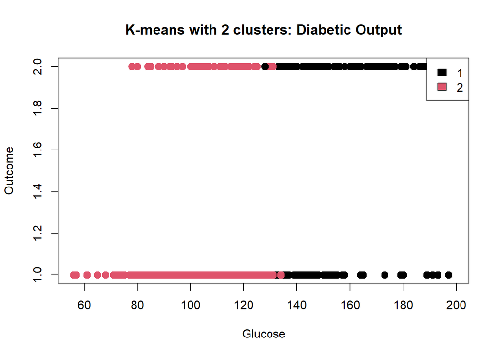

```r
##Graphs:

##Graph for 2 clusters:
##Plot
plot(datasetdiabetesNoNAs$Glucose, datasetdiabetesNoNAs$Outcome, col=kmeans_result_2$cluster,
     main="K-means with 2 clusters: Diabetic Output",
     xlab="Glucose", ylab="Outcome", pch=20, cex=2)
legend("topright", legend=unique(kmeans_result_2$cluster), fill=1:3)
```

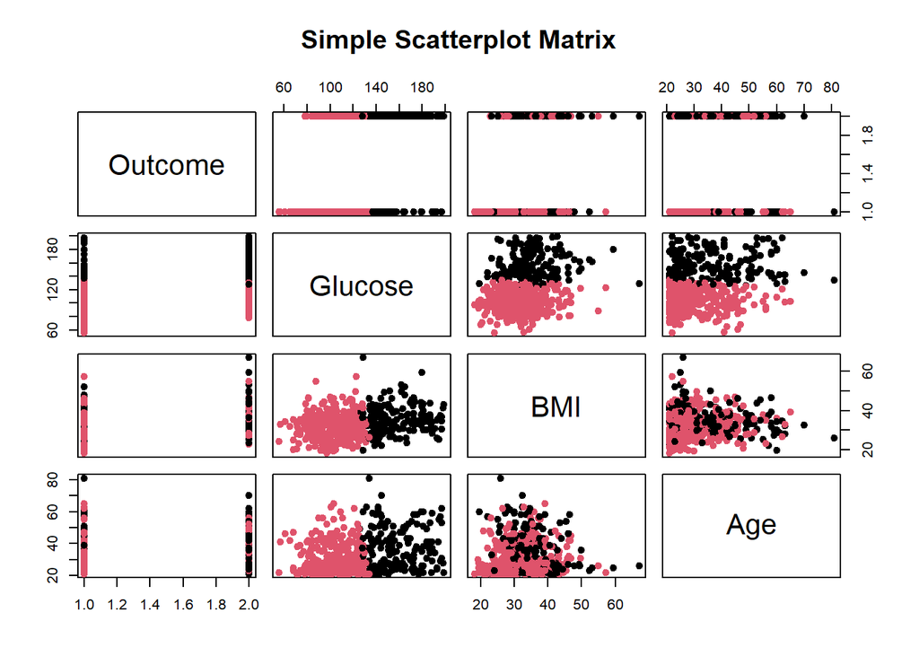

```r
## Scatter Plot
#use of dataset diabetes nas because there the Output is not a factor
pairs(~Outcome+Glucose+BMI+Age,data=na.omit(datasetdiabetesNas[,-5]),
   main="Simple Scatterplot Matrix",col=kmeans_result_2$cluster, pch=20, cex=1.5)
```

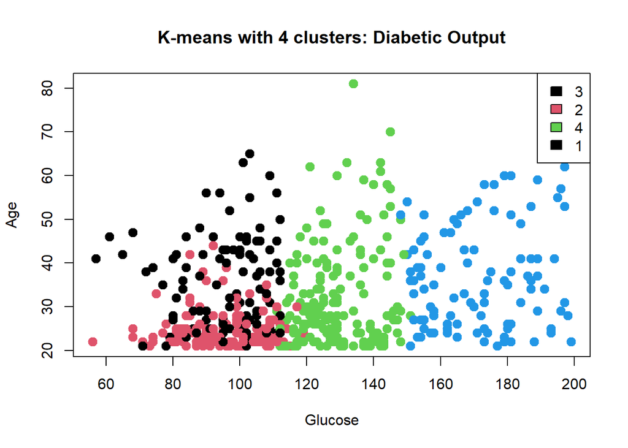

```r
##Graph for 4 clusters:
##Plot:
plot(datasetdiabetesNoNAs$Glucose, datasetdiabetesNoNAs$Age, col=kmeans_result_4$cluster,
     main="K-means with 4 clusters: Diabetic Output",
     xlab="Glucose", ylab="Age", pch=20, cex=2)
legend("topright", legend=unique(kmeans_result_4$cluster), fill=1:3)
```

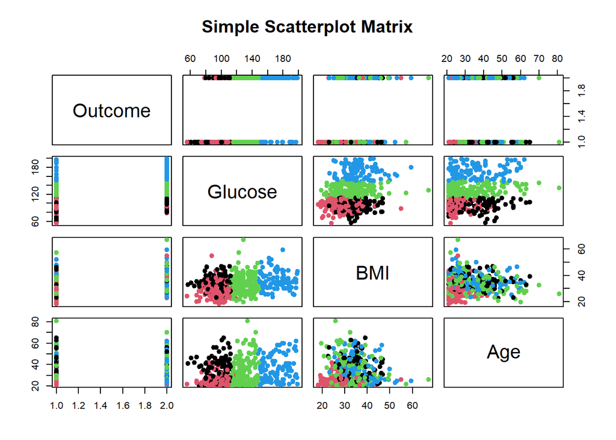

```r
##Scatter Plot:
pairs(~Outcome+Glucose+BMI+Age,data=na.omit(datasetdiabetesNas[,-5]),
   main="Simple Scatterplot Matrix",col=kmeans_result_4$cluster, pch=20, cex=1.5)
```

## Scaled Dataset:

```r
kmeans_result_2_scaled = kmeans(scale_datasediabetes, centers=2)
t1 = table(datasetdiabetesNoNAs$Outcome, kmeans_result_2_scaled$cluster)
t1
```

```
##
##       1   2
##   0 105 250
##   1 126  51
```

```r
kmeans_result_4_scaled = kmeans(scale_datasediabetes, centers=4)
t1 = table(datasetdiabetesNoNAs$Outcome, kmeans_result_4_scaled$cluster)
t1
```

```
##
##       1   2   3   4
##   0 193  55  24  83
##   1  20  33  55  69
```

```r
## acuraccy
n=nrow(scale_datasediabetes)
accuracy=c((249+127)/n*100,(160+115+72+40)/n*100)
print(accuracy)
```

```
## [1] 70.67669 72.74436
```

# 15. K-medoids

For k=2 clusters:

```r
#install.packages("cluster")
library(cluster)
#install.packages("factoextra")
library(factoextra)
# K-medoids for k=2
nrow(datasetdiabetesNoNAs)
```

```
## [1] 532
```

```r
diabetes.pam=pam(na.omit(datasetdiabetesNoNAs), 2)
#diabetes.pam
str(diabetes.pam)
```

```
## List of 10
##  $ medoids   : num [1:2, 1:8] 9 3 152 100 78 68 34 23 34.2 31.6 ...
##   ..- attr(*, "dimnames")=List of 2
##   .. ..$ : chr [1:2] "339" "390"
##   .. ..$ : chr [1:8] "Pregnancies" "Glucose" "BloodPressure" "SkinThickness" ...
##  $ id.med    : int [1:2] 233 268
##  $ clustering: Named int [1:532] 1 2 2 1 2 1 1 1 2 2 ...
##   ..- attr(*, "names")= chr [1:532] "1" "2" "4" "5" ...
##  $ objective : Named num [1:2] 26.6 25.1
##   ..- attr(*, "names")= chr [1:2] "build" "swap"
##  $ isolation : Factor w/ 3 levels "no","L","L*": 1 1
##   ..- attr(*, "names")= chr [1:2] "1" "2"
##  $ clusinfo  : num [1:2, 1:5] 196 336 84.9 56.9 28.8 ...
##   ..- attr(*, "dimnames")=List of 2
##   .. ..$ : NULL
##   .. ..$ : chr [1:5] "size" "max_diss" "av_diss" "diameter" ...
##  $ silinfo   :List of 3
##   ..$ widths         : num [1:532, 1:3] 1 1 1 1 1 1 1 1 1 1 ...
##   .. ..- attr(*, "dimnames")=List of 2
##   .. .. ..$ : chr [1:532] "717" "762" "210" "176" ...
##   .. .. ..$ : chr [1:3] "cluster" "neighbor" "sil_width"
##   ..$ clus.avg.widths: num [1:2] 0.32 0.47
##   ..$ avg.width      : num 0.415
##  $ diss      : NULL
##  $ call      : language pam(x = na.omit(datasetdiabetesNoNAs), k = 2)
##  $ data      : num [1:532, 1:8] 6 1 1 0 3 2 1 5 0 1 ...
##   ..- attr(*, "dimnames")=List of 2
##   .. ..$ : chr [1:532] "1" "2" "4" "5" ...
##   .. ..$ : chr [1:8] "Pregnancies" "Glucose" "BloodPressure" "SkinThickness" ...
##  - attr(*, "class")= chr [1:2] "pam" "partition"
```

```r
#Medoids and pam algorithm
as.vector(diabetes.pam$medoids[1,])
```

```
## [1]   9.000 152.000  78.000  34.000  34.200   0.893  33.000   2.000
```

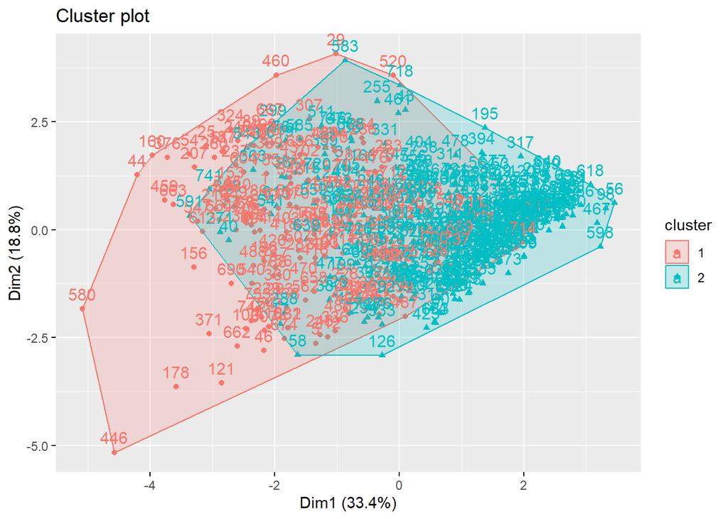

```r
## Graph for K = 2
#summary(diabetes.pam)
fviz_cluster(diabetes.pam)
```

For k= 4 clusters:

```r
# K-medoids for k=4

diabetes.pam4=pam(datasetdiabetesNoNAs, 4)
diabetes.pam4
```

```
## Medoids:
##      ID Pregnancies Glucose BloodPressure SkinThickness  BMI
## 418 287           4     144            82            32 38.5
## 241 162           1      91            64            24 29.2
## 20   11           1     115            70            30 34.6
## 426 294           4     184            78            39 37.0
##     DiabetesPedigreeFunction Age Outcome
## 418                    0.554  37       2
## 241                    0.192  21       1
## 20                     0.529  32       2
## 426                    0.264  31       2
## Clustering vector:
##   1   2   4   5   7   9  14  15  17  19  20  21  24  25  26  28  29  31  32  33
##   1   2   2   3   2   4   4   1   3   2   3   1   3   1   3   2   1   3   1   2
##  35  36  38  39  40  41  43  44  46  48  49  51  52  53  54  55  56  57  58  60
```

[output cut: 58 more lines]

```r
str(diabetes.pam4)
```

```
## List of 10
##  $ medoids   : num [1:4, 1:8] 4 1 1 4 144 91 115 184 82 64 ...
##   ..- attr(*, "dimnames")=List of 2
##   .. ..$ : chr [1:4] "418" "241" "20" "426"
##   .. ..$ : chr [1:8] "Pregnancies" "Glucose" "BloodPressure" "SkinThickness" ...
##  $ id.med    : int [1:4] 287 162 11 294
##  $ clustering: Named int [1:532] 1 2 2 3 2 4 4 1 3 2 ...
##   ..- attr(*, "names")= chr [1:532] "1" "2" "4" "5" ...
##  $ objective : Named num [1:2] 21.4 21.1
##   ..- attr(*, "names")= chr [1:2] "build" "swap"
##  $ isolation : Factor w/ 3 levels "no","L","L*": 1 1 1 1
##   ..- attr(*, "names")= chr [1:4] "1" "2" "3" "4"
##  $ clusinfo  : num [1:4, 1:5] 109 168 194 61 47.8 ...
##   ..- attr(*, "dimnames")=List of 2
##   .. ..$ : NULL
##   .. ..$ : chr [1:5] "size" "max_diss" "av_diss" "diameter" ...
##  $ silinfo   :List of 3
##   ..$ widths         : num [1:532, 1:3] 1 1 1 1 1 1 1 1 1 1 ...
##   .. ..- attr(*, "dimnames")=List of 2
##   .. .. ..$ : chr [1:532] "418" "1" "339" "425" ...
##   .. .. ..$ : chr [1:3] "cluster" "neighbor" "sil_width"
##   ..$ clus.avg.widths: num [1:4] 0.196 0.293 0.172 0.284
##   ..$ avg.width      : num 0.228
##  $ diss      : NULL
##  $ call      : language pam(x = datasetdiabetesNoNAs, k = 4)
##  $ data      : num [1:532, 1:8] 6 1 1 0 3 2 1 5 0 1 ...
##   ..- attr(*, "dimnames")=List of 2
##   .. ..$ : chr [1:532] "1" "2" "4" "5" ...
##   .. ..$ : chr [1:8] "Pregnancies" "Glucose" "BloodPressure" "SkinThickness" ...
##  - attr(*, "class")= chr [1:2] "pam" "partition"
```

```r
#Medoids and pam algorithm
as.vector(diabetes.pam4$medoids[1,])
```

```
## [1]   4.000 144.000  82.000  32.000  38.500   0.554  37.000   2.000
```

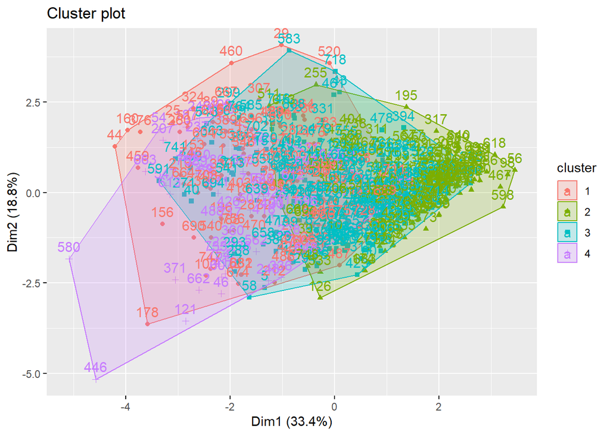

```r
## Graph for K = 2
#summary(diabetes.pam4)
fviz_cluster(diabetes.pam4)
```

# 16.

```r
#install.packages("Rtsne")
library('Rtsne')
diabetes_unique = unique(datasetdiabetesNoNAs)
diabetes_matrix = as.matrix(diabetes_unique[,1:7])
print( head( diabetes_matrix ) )
```

```
##   Pregnancies Glucose BloodPressure SkinThickness  BMI DiabetesPedigreeFunction
## 1           6     148            72            35 33.6                    0.627
## 2           1      85            66            29 26.6                    0.351
## 4           1      89            66            23 28.1                    0.167
## 5           0     137            40            35 43.1                    2.288
## 7           3      78            50            32 31.0                    0.248
## 9           2     197            70            45 30.5                    0.158
##   Age
## 1  50
## 2  31
## 4  21
## 5  33
## 7  26
## 9  53
```

```r
tsne_out = Rtsne(diabetes_unique,pca=TRUE,perplexity=30,theta=0.2)
names(tsne_out)
```

```
##  [1] "N"                   "Y"                   "costs"
##  [4] "itercosts"           "origD"               "perplexity"
##  [7] "theta"               "max_iter"            "stop_lying_iter"
## [10] "mom_switch_iter"     "momentum"            "final_momentum"
## [13] "eta"                 "exaggeration_factor"
```

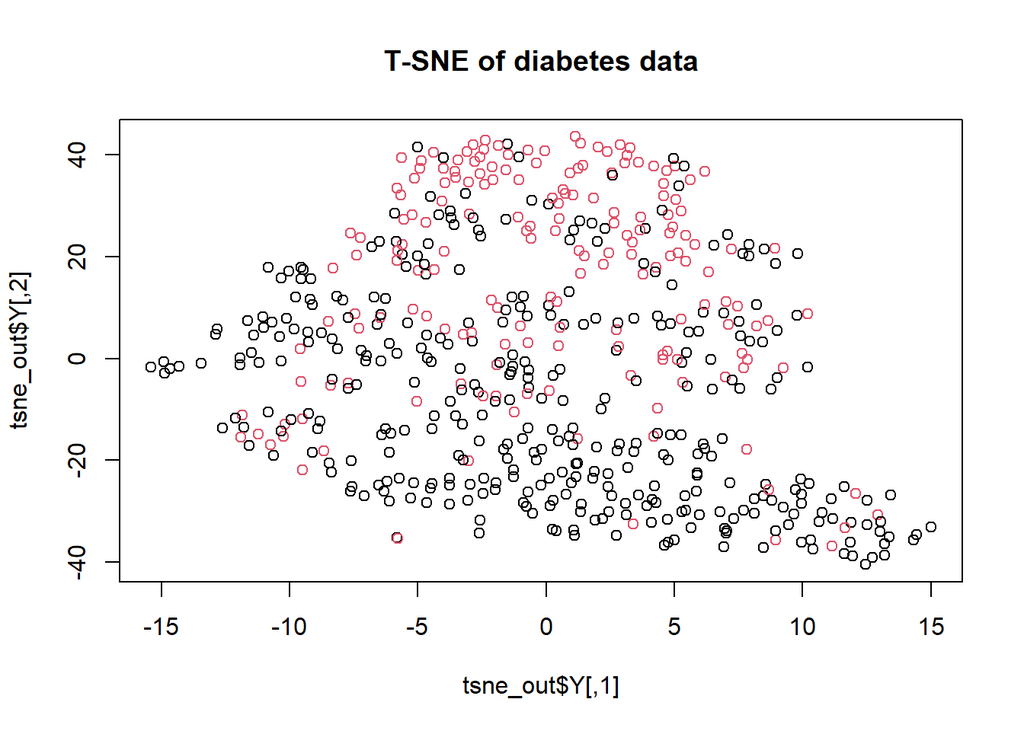

```r
plot(tsne_out$Y,col=diabetes_unique$Outcome,main='T-SNE of diabetes data')
```

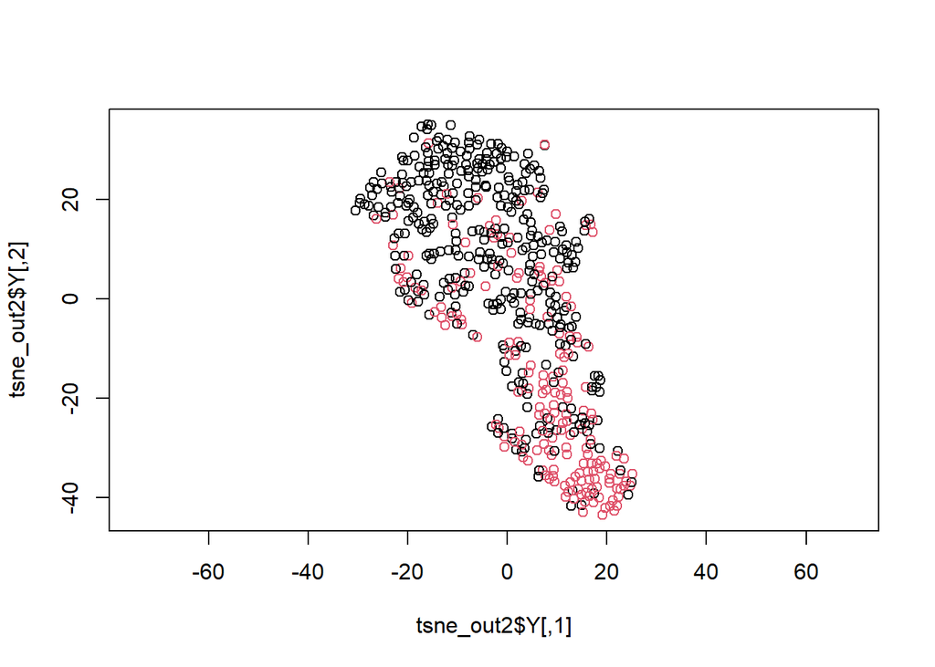

```r
tsne_out2 = Rtsne(diabetes_unique,pca=FALSE, theta=0.0)

tsne_out2 = Rtsne(dist(normalize_input(diabetes_matrix)), theta=0.0)
plot(tsne_out2$Y,col=diabetes_unique$Outcome, asp=1)
```

With K -Means

```r
tk = kmeans((tsne_out2$Y),2)
tk$cluster
```

```
##   [1] 2 1 1 1 1 2 2 2 2 1 1 2 2 2 2 1 2 1 2 1 2 1 1 1 1 2 1 2 2 1 1 1 1 1 2 2 1
##  [38] 2 1 1 2 1 1 1 2 1 2 2 1 1 1 1 1 1 1 1 1 2 1 1 1 2 2 1 1 1 2 1 1 2 1 1 2 2
##  [75] 1 2 1 1 2 1 1 1 1 1 1 2 2 1 1 1 1 1 1 1 1 2 1 1 1 2 2 2 2 1 1 1 2 2 1 2 1
## [112] 1 2 1 1 1 1 2 2 1 2 2 2 1 2 2 1 2 1 1 2 1 1 1 1 1 2 1 2 1 2 2 2 1 2 1 1 1
## [149] 2 2 1 1 2 2 2 2 1 1 2 2 2 1 1 1 2 2 2 1 1 1 1 1 1 1 1 2 2 2 1 2 1 2 1 1 1
## [186] 1 1 1 1 2 2 2 2 2 1 1 1 1 2 1 2 2 2 1 2 1 2 2 1 1 1 1 1 2 1 1 1 1 1 1 1 1
## [223] 2 1 2 1 1 1 2 1 1 2 2 1 1 2 1 1 1 1 1 1 2 2 1 2 1 1 1 2 2 1 1 1 2 1 1 1 1
## [260] 1 1 1 1 1 1 1 2 1 1 1 1 1 1 2 2 2 1 1 2 1 1 2 2 2 2 1 2 1 2 1 1 1 2 2 2 2
## [297] 1 1 1 1 2 1 2 1 1 1 2 1 1 1 1 1 1 1 2 1 2 2 2 1 1 1 1 1 2 2 2 1 2 1 1 2 2
## [334] 2 2 1 1 2 2 2 1 1 1 1 2 1 2 2 1 1 1 1 2 1 1 1 1 1 2 2 2 1 2 1 1 1 1 1 1 1
## [371] 2 2 1 1 1 1 1 2 2 1 2 2 1 1 1 1 1 1 1 2 1 1 1 1 1 2 1 1 1 2 1 1 2 2 1 2 2
## [408] 1 2 1 1 1 2 2 1 1 1 2 2 1 2 1 2 1 1 2 2 1 2 1 1 1 1 1 1 1 1 2 1 1 1 1 1 2
## [445] 2 2 2 1 1 1 2 1 2 1 2 1 2 2 2 1 1 2 1 1 2 2 1 1 2 1 1 2 1 1 1 2 2 1 2 2 2
## [482] 1 1 2 2 1 1 1 1 2 2 1 1 2 2 1 1 1 1 1 2 1 1 1 2 1 2 1 1 2 1 1 1 1 1 2 1 2
## [519] 1 2 2 1 2 2 2 2 1 2 1 1 1 1
```

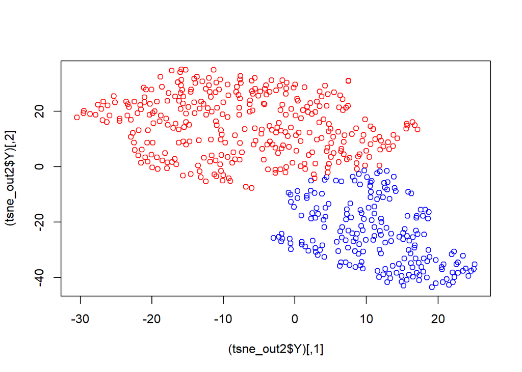

```r
colors = c("red","blue")
colors = colors[tk$cluster]
plot( (tsne_out2$Y), col=colors )
```

# 17.

```r
#library(cluster.stats)

#clustering vector:
clustering_vector <- as.data.frame(diabetes.pam$clustering)

#silhouette score
silhouette_scores <- as.data.frame(diabetes.pam$silinfo$widths)
head(silhouette_scores)
```

```
##     cluster neighbor sil_width
## 717       1        2 0.5444252
## 762       1        2 0.5327901
## 210       1        2 0.5317113
## 176       1        2 0.5310542
## 426       1        2 0.5307788
## 613       1        2 0.5279580
```

```r
names(silhouette_scores)
```

```
## [1] "cluster"   "neighbor"  "sil_width"
```

```r
#most ambiguous data
y=min(silhouette_scores$sil_width)
y
```

```
## [1] -0.1537411
```

```r
#row with minimum value for silhouette score
row_with_minvalue <- which(silhouette_scores$sil_width == y)
row_with_minvalue
```

```
## [1] 196
```

```r
myrow=row_with_minvalue[[1]][1]
myrow
```

```
## [1] 196
```

```r
silohouette_scores_myrow <- as.data.frame(diabetes.pam$silinfo)[myrow,]
silohouette_scores_myrow #Belongs to cluster 1
```

```
##     widths.cluster widths.neighbor widths.sil_width clus.avg.widths avg.width
## 595              1               2       -0.1537411       0.4698977 0.4147073
```

```r
target_row_index <- which(rownames(clustering_vector) == myrow)
target_row_index
```

```
## [1] 128
```

```r
#select the row

prob <- predict(newmodel, newdata=datasetdiabetesNoNAs[target_row_index,], type="response")
prob
```

```
##       196
## 0.6541096
```

```r
#prob <- predict(newmodel, newdata=datasetdiabetesNoNAs, type="response")
#prob

#Real Outcome
datasetdiabetesNoNAs[target_row_index,]
```

```
##     Pregnancies Glucose BloodPressure SkinThickness  BMI
## 196           5     158            84            41 39.4
##     DiabetesPedigreeFunction Age Outcome
## 196                    0.395  29       1
```